# Reproducible Research: Peer Assessment 1

## Imputing missing values

```r
# Calculate and report the total number of missing values in the dataset (i.e. the total number of rows with NAs)
num_na <- sum(is.na(activity_data))
num_na
```

[1] 2304

```r
# only steps taken has missing values so we replace these with the mean
summary(activity_data)
```

```
 steps             date               interval
```

Min. : 0.00 Min. :2012-10-01 Min. : 0.0  
1st Qu.: 0.00 1st Qu.:2012-10-16 1st Qu.: 588.8  
Median : 0.00 Median :2012-10-31 Median :1177.5  
Mean : 37.38 Mean :2012-10-31 Mean :1177.5  
3rd Qu.: 12.00 3rd Qu.:2012-11-15 3rd Qu.:1766.2  
Max. :806.00 Max. :2012-11-30 Max. :2355.0  
NA’s :2304

```r
str(activity_data)
```

‘data.frame’: 17568 obs. of 3 variables: $ steps : int NA NA NA NA NA NA NA NA NA NA … $ date : Date, format: “2012-10-01” “2012-10-01” … $ interval: int 0 5 10 15 20 25 30 35 40 45 …

```r
imputed_activity_data <- activity_data
imputed_activity_data$steps[is.na(imputed_activity_data$steps)] <- mean(imputed_activity_data$steps, na.rm = TRUE)
str(imputed_activity_data)
```

‘data.frame’: 17568 obs. of 3 variables: $ steps : num 37.4 37.4 37.4 37.4 37.4 … $ date : Date, format: “2012-10-01” “2012-10-01” … $ interval: int 0 5 10 15 20 25 30 35 40 45 …

```r
summary(imputed_activity_data)
```

```
 steps             date               interval
```

Min. : 0.00 Min. :2012-10-01 Min. : 0.0  
1st Qu.: 0.00 1st Qu.:2012-10-16 1st Qu.: 588.8  
Median : 0.00 Median :2012-10-31 Median :1177.5  
Mean : 37.38 Mean :2012-10-31 Mean :1177.5  
3rd Qu.: 37.38 3rd Qu.:2012-11-15 3rd Qu.:1766.2  
Max. :806.00 Max. :2012-11-30 Max. :2355.0

## Are there differences in activity patterns between weekdays and weekends?

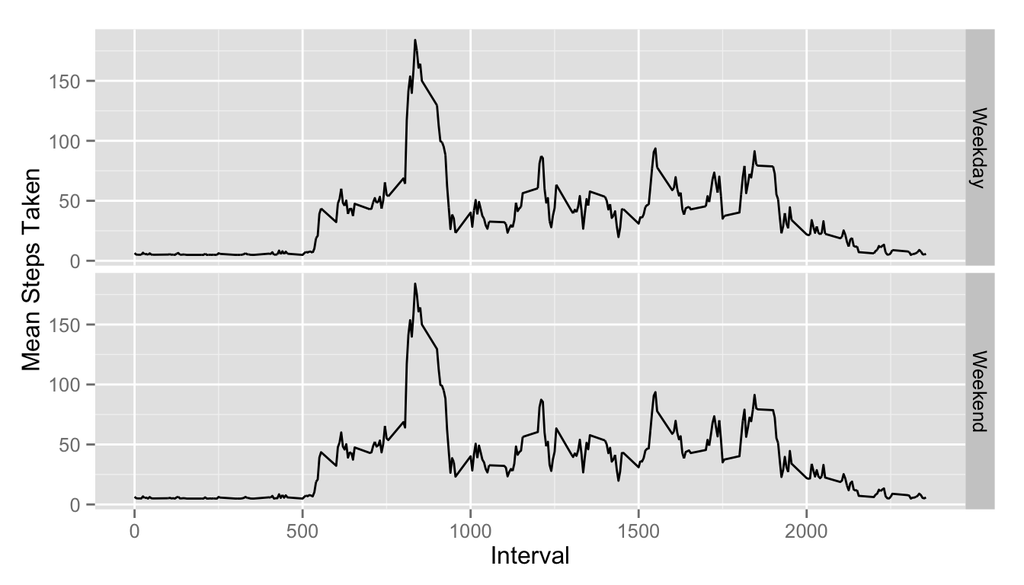

```r
imputed_activity_data$weekday_bool <- weekdays(imputed_activity_data$date) == "Saturday" | weekdays(imputed_activity_data$date) == "Sunday"
levels(imputed_activity_data$weekday_bool) <- c("Weekday", "Weekend")
imputed_activity_data$weekday_bool[imputed_activity_data$weekday_bool == TRUE] <- "Weekend"
imputed_activity_data$weekday_bool[imputed_activity_data$weekday_bool == FALSE] <- "Weekday"

library(ggplot2)
imputed_activity_data$mean_step_interval <- tapply(imputed_activity_data$steps, imputed_activity_data$interval, mean)
# plot of activity
activity_plot <- ggplot(data = imputed_activity_data, aes(x = interval, y = mean_step_interval)) + geom_line() + xlab("Interval") + ylab("Mean Steps Taken")
activity_plot + facet_grid(weekday_bool~.)
```